# Employee Attrition: Binary Classification Lab

From operational questions to retention decisions

Analytics Solutions Bootcamp

07 September 2026

```r
knitr::opts_chunk$set(
  echo = TRUE,
  message = FALSE,
  warning = FALSE,
  fig.width = 9,
  fig.height = 5
)

required_packages <- c(
  "modeldata", "tidyverse", "janitor", "rsample",
  "rpart", "rpart.plot", "yardstick", "broom", "scales"
)

missing_packages <- required_packages[
  !required_packages %in% rownames(installed.packages())
]

if (length(missing_packages) > 0) {
  stop(
    "Install the missing packages first: ",
    paste(missing_packages, collapse = ", ")
  )
}

library(modeldata)
library(tidyverse)
library(janitor)
library(rsample)
library(rpart)
library(rpart.plot)
library(yardstick)
library(broom)
library(scales)

set.seed(123)
```

# 1 Lab scenario

An organization wants to use its historical employee records to support a targeted retention program. The goal is not simply to build the model with the highest accuracy. HR needs a solution that can identify employees who may need support while keeping the number of employees contacted manageable.

The response variable is `attrition`:

- `Yes`: the employee left the organization.
- `No`: the employee stayed.

## 1.1 Operational questions

This lab will answer the following questions:

1. What proportion of employees left the organization?
2. Which employee groups have relatively high historical attrition rates?
3. Can employee information help HR prioritize employees for a retention review?
4. Which model—logistic regression or a decision tree—better supports the operational goal?
5. How many actual attrition cases would each model miss?
6. If HR can only review a limited number of employees, how should the classification threshold be selected?
7. What patterns can HR investigate without incorrectly treating model results as causal explanations?

> **Important:** This is a synthetic dataset intended for instruction. A real employee-risk system requires privacy review, fairness testing, human oversight, and validation using current organizational data. Predictions should support employee assistance—not punitive decisions.

# 2 1. Load and understand the data

```r
data(attrition, package = "modeldata")

attrition_data <- attrition |>
  clean_names() |>
  mutate(attrition = factor(attrition, levels = c("No", "Yes")))

glimpse(attrition_data)
```

```
## Rows: 1,470
## Columns: 31
## $ age                        <int> 41, 49, 37, 33, 27, 32, 59, 30, 38, 36, 35,…
## $ attrition                  <fct> Yes, No, Yes, No, No, No, No, No, No, No, N…
## $ business_travel            <fct> Travel_Rarely, Travel_Frequently, Travel_Ra…
## $ daily_rate                 <int> 1102, 279, 1373, 1392, 591, 1005, 1324, 135…
## $ department                 <fct> Sales, Research_Development, Research_Devel…
## $ distance_from_home         <int> 1, 8, 2, 3, 2, 2, 3, 24, 23, 27, 16, 15, 26…
## $ education                  <ord> College, Below_College, College, Master, Be…
## $ education_field            <fct> Life_Sciences, Life_Sciences, Other, Life_S…
## $ environment_satisfaction   <ord> Medium, High, Very_High, Very_High, Low, Ve…
## $ gender                     <fct> Female, Male, Male, Female, Male, Male, Fem…
## $ hourly_rate                <int> 94, 61, 92, 56, 40, 79, 81, 67, 44, 94, 84,…
## $ job_involvement            <ord> High, Medium, Medium, High, High, High, Ver…
## $ job_level                  <int> 2, 2, 1, 1, 1, 1, 1, 1, 3, 2, 1, 2, 1, 1, 1…
```

[output cut: 18 more lines]

```r
tibble(
  employees = nrow(attrition_data),
  variables = ncol(attrition_data),
  duplicate_rows = sum(duplicated(attrition_data)),
  missing_values = sum(is.na(attrition_data))
)
```

```
## # A tibble: 1 × 4
##   employees variables duplicate_rows missing_values
##       <int>     <int>          <int>          <int>
## 1      1470        31              0              0
```

Before modeling, confirm that the response has exactly two possible classes.

```r
attrition_data |>
  count(attrition) |>
  mutate(proportion = percent(n / sum(n), accuracy = 0.1))
```

```
##   attrition    n proportion
## 1        No 1233      83.9%
## 2       Yes  237      16.1%
```

# 3 2. Explore the operational problem

## 3.1 Overall attrition rate

```r
overall_attrition <- attrition_data |>
  summarise(
    employees = n(),
    employees_who_left = sum(attrition == "Yes"),
    attrition_rate = mean(attrition == "Yes")
  )

overall_attrition
```

```
##   employees employees_who_left attrition_rate
## 1      1470                237      0.1612245
```

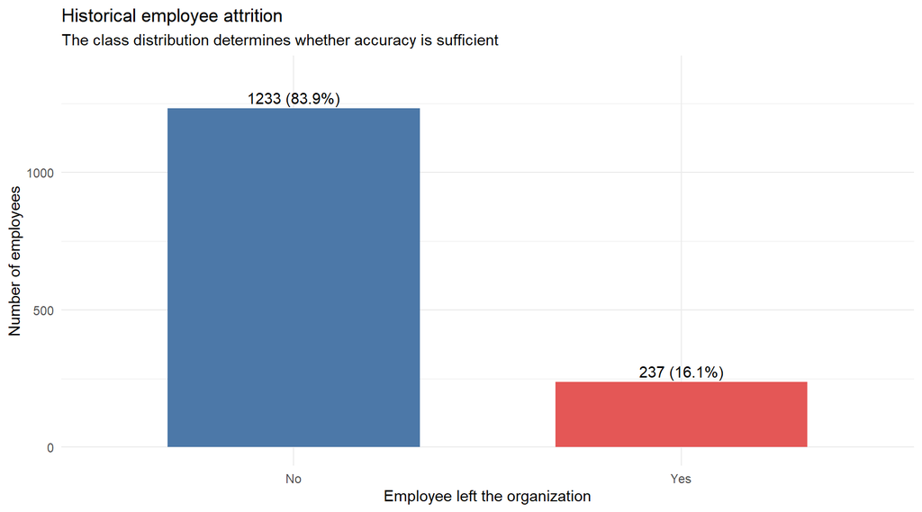

```r
attrition_data |>
  count(attrition) |>
  mutate(share = n / sum(n)) |>
  ggplot(aes(attrition, n, fill = attrition)) +
  geom_col(width = 0.65, show.legend = FALSE) +
  geom_text(
    aes(label = paste0(n, " (", percent(share, accuracy = 0.1), ")")),
    vjust = -0.4
  ) +
  scale_fill_manual(values = c("No" = "#4C78A8", "Yes" = "#E45756")) +
  expand_limits(y = max(table(attrition_data$attrition)) * 1.1) +
  labs(
    title = "Historical employee attrition",
    subtitle = "The class distribution determines whether accuracy is sufficient",
    x = "Employee left the organization",
    y = "Number of employees"
  ) +
  theme_minimal()
```

## 3.2 Where is attrition concentrated?

The following summaries help HR decide which workforce conditions deserve further investigation. They describe associations and do not establish causes.

```r
attrition_summary <- function(data, group_variable) {
  data |>
    group_by({{ group_variable }}) |>
    summarise(
      employees = n(),
      employees_who_left = sum(attrition == "Yes"),
      attrition_rate = mean(attrition == "Yes"),
      .groups = "drop"
    ) |>
    arrange(desc(attrition_rate))
}
```

```r
attrition_summary(attrition_data, over_time)
```

```
## # A tibble: 2 × 4
##   over_time employees employees_who_left attrition_rate
##   <fct>         <int>              <int>          <dbl>
## 1 Yes             416                127          0.305
## 2 No             1054                110          0.104
```

```r
attrition_summary(attrition_data, job_role)
```

```
## # A tibble: 9 × 4
##   job_role                  employees employees_who_left attrition_rate
##   <fct>                         <int>              <int>          <dbl>
## 1 Sales_Representative             83                 33         0.398
## 2 Laboratory_Technician           259                 62         0.239
## 3 Human_Resources                  52                 12         0.231
## 4 Sales_Executive                 326                 57         0.175
## 5 Research_Scientist              292                 47         0.161
## 6 Manufacturing_Director          145                 10         0.0690
## 7 Healthcare_Representative       131                  9         0.0687
## 8 Manager                         102                  5         0.0490
## 9 Research_Director                80                  2         0.025
```

```r
attrition_summary(attrition_data, business_travel)
```

```
## # A tibble: 3 × 4
##   business_travel   employees employees_who_left attrition_rate
##   <fct>                 <int>              <int>          <dbl>
## 1 Travel_Frequently       277                 69          0.249
## 2 Travel_Rarely          1043                156          0.150
## 3 Non-Travel              150                 12          0.08
```

```r
attrition_summary(attrition_data, job_satisfaction)
```

```
## # A tibble: 4 × 4
##   job_satisfaction employees employees_who_left attrition_rate
##   <ord>                <int>              <int>          <dbl>
## 1 Low                    289                 66          0.228
## 2 High                   442                 73          0.165
## 3 Medium                 280                 46          0.164
## 4 Very_High              459                 52          0.113
```

```r
attrition_data |>
  group_by(attrition) |>
  summarise(
    employees = n(),
    median_monthly_income = median(monthly_income),
    median_years_at_company = median(years_at_company),
    median_distance_from_home = median(distance_from_home),
    .groups = "drop"
  )
```

```
## # A tibble: 2 × 5
##   attrition employees median_monthly_income median_years_at_company
##   <fct>         <int>                 <int>                   <int>
## 1 No             1233                  5204                       6
## 2 Yes             237                  3202                       3
## # ℹ 1 more variable: median_distance_from_home <int>
```

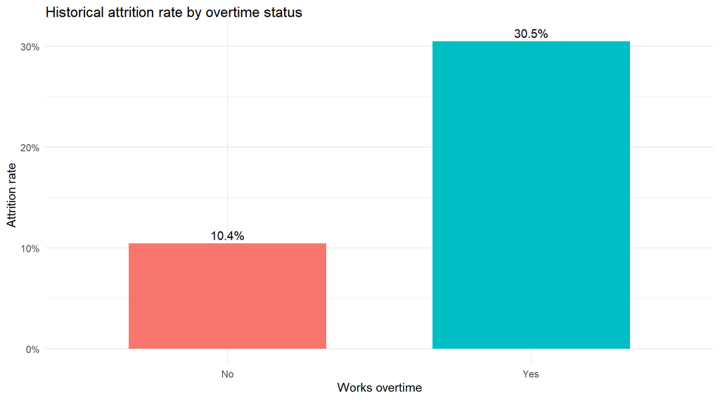

```r
attrition_summary(attrition_data, over_time) |>
  ggplot(aes(over_time, attrition_rate, fill = over_time)) +
  geom_col(width = 0.65, show.legend = FALSE) +
  geom_text(
    aes(label = percent(attrition_rate, accuracy = 0.1)),
    vjust = -0.4
  ) +
  scale_y_continuous(labels = percent, limits = c(0, NA)) +
  labs(
    title = "Historical attrition rate by overtime status",
    x = "Works overtime",
    y = "Attrition rate"
  ) +
  theme_minimal()
```

### 3.2.1 Discussion

- Which groups have the highest attrition rates?
- Are these also large employee groups, or only small groups with high rates?
- What additional data would HR need before designing an intervention?
- Which variables might reflect a condition HR can improve?

# 4 3. Prepare training and test data

We remove administrative constants and identifiers because they do not provide generalizable employee information. We also exclude `gender` from modeling to avoid directly using a protected characteristic in individual risk scores. In a real project, protected attributes may still be retained separately for fairness auditing.

```r
model_data <- attrition_data |>
  select(
    -any_of(c(
      "employee_number", "employee_count", "over18",
      "standard_hours", "gender"
    ))
  )

model_data |>
  summarise(across(everything(), ~ sum(is.na(.x)))) |>
  pivot_longer(everything(), names_to = "variable", values_to = "missing") |>
  filter(missing > 0)
```

```
## # A tibble: 0 × 2
## # ℹ 2 variables: variable <chr>, missing <int>
```

Attrition is the minority class, so we use a **stratified split** to preserve approximately the same class proportions in the training and test sets.

```r
attrition_split <- initial_split(
  model_data,
  prop = 0.80,
  strata = attrition
)

train_data <- training(attrition_split)
test_data  <- testing(attrition_split)

bind_rows(
  train_data |> count(attrition) |> mutate(dataset = "Training"),
  test_data  |> count(attrition) |> mutate(dataset = "Test")
) |>
  group_by(dataset) |>
  mutate(proportion = percent(n / sum(n), accuracy = 0.1)) |>
  ungroup()
```

```
## # A tibble: 4 × 4
##   attrition     n dataset  proportion
##   <fct>     <int> <chr>    <chr>
## 1 No          986 Training 83.9%
## 2 Yes         189 Training 16.1%
## 3 No          247 Test     83.7%
## 4 Yes          48 Test     16.3%
```

The test set is kept untouched during model fitting. It represents employees whose outcomes were not used to estimate either model.

# 5 4. Establish a frequency-based baseline

Following the **zero-rule** approach, the baseline predicts the majority class (`No`) for every employee. A useful model should provide operational value beyond this naive rule.

```r
baseline_predictions <- test_data |>
  transmute(
    truth = attrition,
    .pred_class = factor("No", levels = levels(attrition))
  )

baseline_accuracy <- accuracy(
  baseline_predictions,
  truth = truth,
  estimate = .pred_class
)

baseline_accuracy
```

```
## # A tibble: 1 × 3
##   .metric  .estimator .estimate
##   <chr>    <chr>          <dbl>
## 1 accuracy binary         0.837
```

Accuracy may look high even though this baseline identifies no employees who actually leave. This is why recall, precision, F1 score, and the confusion matrix are necessary.

# 6 5. Build a logistic regression model

Logistic regression estimates each employee’s probability of attrition. Its coefficients can help identify associations after controlling for the other included variables.

```r
logistic_model <- glm(
  attrition ~ .,
  data = train_data,
  family = binomial(link = "logit")
)

summary(logistic_model)
```

```
##
## Call:
## glm(formula = attrition ~ ., family = binomial(link = "logit"),
##     data = train_data)
##
## Coefficients:
##                                    Estimate Std. Error z value Pr(>|z|)
## (Intercept)                      -1.725e+01  6.790e+02  -0.025 0.979736
## age                              -2.273e-02  1.551e-02  -1.466 0.142647
## business_travelTravel_Frequently  2.206e+00  5.234e-01   4.214 2.51e-05 ***
## business_travelTravel_Rarely      1.389e+00  4.884e-01   2.844 0.004460 **
## daily_rate                       -3.574e-04  2.505e-04  -1.427 0.153674
## departmentResearch_Development    1.346e+01  6.790e+02   0.020 0.984184
## departmentSales                   1.335e+01  6.790e+02   0.020 0.984308
## distance_from_home                4.535e-02  1.237e-02   3.667 0.000246 ***
## education.L                      -3.127e-01  4.735e-01  -0.661 0.508918
## education.Q                      -4.354e-01  4.037e-01  -1.079 0.280748
## education.C                      -1.271e-01  3.019e-01  -0.421 0.673716
## education^4                      -5.814e-02  2.119e-01  -0.274 0.783802
## education_fieldLife_Sciences     -5.591e-01  9.447e-01  -0.592 0.553950
## education_fieldMarketing         -6.921e-02  9.943e-01  -0.070 0.944507
## education_fieldMedical           -5.324e-01  9.486e-01  -0.561 0.574609
## education_fieldOther             -5.022e-01  1.009e+00  -0.498 0.618512
## education_fieldTechnical_Degree   5.526e-01  9.611e-01   0.575 0.565346
## environment_satisfaction.L       -9.505e-01  2.043e-01  -4.652 3.29e-06 ***
## environment_satisfaction.Q        5.533e-01  2.081e-01   2.659 0.007844 **
## environment_satisfaction.C       -2.983e-01  2.118e-01  -1.408 0.159048
## hourly_rate                       1.325e-04  5.017e-03   0.026 0.978930
## job_involvement.L                -1.493e+00  3.934e-01  -3.795 0.000148 ***
## job_involvement.Q                -9.868e-02  3.095e-01  -0.319 0.749841
## job_involvement.C                -3.128e-01  2.007e-01  -1.559 0.119017
## job_level                        -3.995e-02  3.556e-01  -0.112 0.910528
## job_roleHuman_Resources           1.492e+01  6.790e+02   0.022 0.982465
## job_roleLaboratory_Technician     1.697e+00  5.605e-01   3.028 0.002459 **
## job_roleManager                  -4.515e-01  1.078e+00  -0.419 0.675463
## job_roleManufacturing_Director    2.660e-01  6.046e-01   0.440 0.659997
## job_roleResearch_Director        -1.095e+00  1.077e+00  -1.017 0.309205
## job_roleResearch_Scientist        7.458e-01  5.801e-01   1.286 0.198579
## job_roleSales_Executive           1.145e+00  1.300e+00   0.881 0.378361
## job_roleSales_Representative      2.164e+00  1.364e+00   1.587 0.112602
```

[output cut: 19 more lines]

```
## work_life_balance.C               1.440e-01  1.961e-01   0.734 0.462727
## years_at_company                  1.401e-01  4.459e-02   3.143 0.001674 **
## years_in_current_role            -1.563e-01  5.103e-02  -3.063 0.002193 **
## years_since_last_promotion        1.455e-01  4.661e-02   3.123 0.001793 **
## years_with_curr_manager          -1.579e-01  5.142e-02  -3.070 0.002139 **
## ---
## Signif. codes:  0 '***' 0.001 '**' 0.01 '*' 0.05 '.' 0.1 ' ' 1
##
## (Dispersion parameter for binomial family taken to be 1)
##
##     Null deviance: 1036.53  on 1174  degrees of freedom
## Residual deviance:  679.83  on 1118  degrees of freedom
## AIC: 793.83
##
## Number of Fisher Scoring iterations: 15
```

Odds ratios are easier to interpret than raw log-odds coefficients. Values above 1 are associated with higher odds of attrition; values below 1 are associated with lower odds, holding the other included predictors constant.

```r
logistic_odds_ratios <- tidy(
  logistic_model,
  conf.int = TRUE,
  exponentiate = TRUE
) |>
  filter(term != "(Intercept)") |>
  arrange(desc(abs(log(estimate))))

logistic_odds_ratios |>
  select(term, odds_ratio = estimate, conf.low, conf.high, p.value) |>
  slice_head(n = 15)
```

```
## # A tibble: 15 × 5
##    term                              odds_ratio  conf.low conf.high  p.value
##    <chr>                                  <dbl>     <dbl>     <dbl>    <dbl>
##  1 job_roleHuman_Resources          3025493.    7.02e+100 3.36e+127 9.82e- 1
##  2 departmentResearch_Development    700872.    2.07e+ 79 6.67e+125 9.84e- 1
##  3 departmentSales                   630387.    3.57e+173 3.93e+130 9.84e- 1
##  4 business_travelTravel_Frequently       9.08  3.44e+  0 2.72e+  1 2.51e- 5
##  5 job_roleSales_Representative           8.70  5.70e-  1 1.39e+  2 1.13e- 1
##  6 over_timeYes                           7.15  4.69e+  0 1.11e+  1 2.45e-19
##  7 job_roleLaboratory_Technician          5.46  1.91e+  0 1.75e+  1 2.46e- 3
##  8 marital_statusSingle                   4.70  2.19e+  0 1.04e+  1 9.10e- 5
##  9 job_involvement.L                      0.225 1.01e-  1 4.75e-  1 1.48e- 4
## 10 business_travelTravel_Rarely           4.01  1.64e+  0 1.13e+  1 4.46e- 3
## 11 job_roleSales_Executive                3.14  2.30e-  1 4.46e+  1 3.78e- 1
## 12 job_roleResearch_Director              0.335 3.16e-  2 2.44e+  0 3.09e- 1
## 13 environment_satisfaction.L             0.387 2.58e-  1 5.75e-  1 3.29e- 6
## 14 job_satisfaction.L                     0.418 2.75e-  1 6.28e-  1 3.19e- 5
## 15 job_roleResearch_Scientist             2.11  7.04e-  1 6.95e+  0 1.99e- 1
```

```r
logistic_predictions <- test_data |>
  transmute(
    truth = attrition,
    .pred_yes = predict(
      logistic_model,
      newdata = test_data,
      type = "response"
    ),
    .pred_no = 1 - .pred_yes,
    .pred_class = factor(
      if_else(.pred_yes >= 0.50, "Yes", "No"),
      levels = c("No", "Yes")
    )
  )
```

# 7 6. Build a decision tree model

A decision tree creates a hierarchy of rules. Its main operational advantage is that HR stakeholders can inspect the sequence of conditions leading to a classification.

We set `cp` below its final value first, then use cross-validation error to select and prune the tree.

```r
tree_full <- rpart(
  attrition ~ .,
  data = train_data,
  method = "class",
  parms = list(split = "information"),
  control = rpart.control(cp = 0.001, minsplit = 20, xval = 10)
)

printcp(tree_full)
```

```
##
## Classification tree:
## rpart(formula = attrition ~ ., data = train_data, method = "class",
##     parms = list(split = "information"), control = rpart.control(cp = 0.001,
##         minsplit = 20, xval = 10))
##
## Variables actually used in tree construction:
##  [1] age                   daily_rate            distance_from_home
##  [4] education_field       hourly_rate           job_involvement
##  [7] job_role              job_satisfaction      marital_status
## [10] monthly_income        monthly_rate          num_companies_worked
## [13] over_time             total_working_years   years_in_current_role
##
## Root node error: 189/1175 = 0.16085
##
## n= 1175
##
##           CP nsplit rel error  xerror     xstd
## 1  0.0661376      0   1.00000 1.00000 0.066633
## 2  0.0264550      2   0.86772 0.95238 0.065323
## 3  0.0185185      5   0.78836 0.92593 0.064571
## 4  0.0158730      7   0.75132 0.96296 0.065619
## 5  0.0132275      8   0.73545 0.96296 0.065619
## 6  0.0088183     10   0.70899 1.00529 0.066775
## 7  0.0063492     13   0.68254 1.03175 0.067476
## 8  0.0052910     18   0.65079 1.04762 0.067889
## 9  0.0035273     20   0.64021 1.06349 0.068296
## 10 0.0019841     23   0.62963 1.07937 0.068698
## 11 0.0010000     31   0.61376 1.12169 0.069743
```

```r
best_cp <- tree_full$cptable[
  which.min(tree_full$cptable[, "xerror"]),
  "CP"
]

decision_tree <- prune(tree_full, cp = best_cp)
```

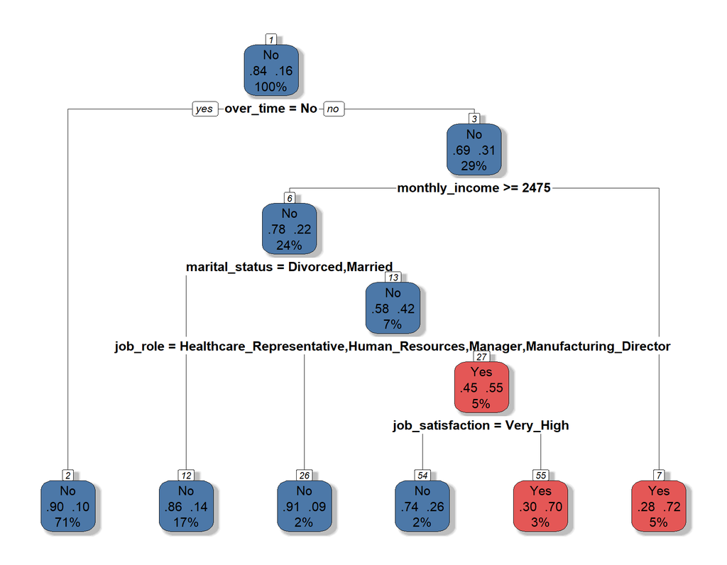

```r
rpart.plot(
  decision_tree,
  type = 2,
  extra = 104,
  fallen.leaves = TRUE,
  box.palette = c("#4C78A8", "#E45756"),
  shadow.col = "gray",
  nn = TRUE
)
```

```r
tree_importance <- enframe(
  decision_tree$variable.importance,
  name = "variable",
  value = "importance"
) |>
  mutate(importance = importance / sum(importance)) |>
  arrange(desc(importance))

tree_importance
```

```
## # A tibble: 16 × 2
##    variable                 importance
##    <chr>                         <dbl>
##  1 over_time                   0.303
##  2 monthly_income              0.239
##  3 marital_status              0.103
##  4 job_role                    0.0903
##  5 stock_option_level          0.0582
##  6 total_working_years         0.0491
##  7 job_satisfaction            0.0447
##  8 age                         0.0413
##  9 monthly_rate                0.0167
## 10 job_level                   0.0128
## 11 daily_rate                  0.0112
## 12 department                  0.00962
## 13 distance_from_home          0.00705
## 14 training_times_last_year    0.00705
## 15 years_at_company            0.00397
## 16 business_travel             0.00235
```

Variable importance identifies variables useful for splitting the historical records. It does not prove that changing a variable will cause attrition to decrease.

```r
tree_probabilities <- predict(
  decision_tree,
  newdata = test_data,
  type = "prob"
)

tree_predictions <- test_data |>
  transmute(
    truth = attrition,
    .pred_no = tree_probabilities[, "No"],
    .pred_yes = tree_probabilities[, "Yes"],
    .pred_class = factor(
      if_else(.pred_yes >= 0.50, "Yes", "No"),
      levels = c("No", "Yes")
    )
  )
```

# 8 7. Evaluate both models

For this retention use case, `Yes` is the event of interest. A false negative is an employee who actually leaves but whom the model labels as likely to stay. If early support is the objective, these missed cases may be more costly than false positives.

```r
classification_metrics <- function(predictions, model_name) {
  bind_rows(
    accuracy(predictions, truth, .pred_class),
    precision(predictions, truth, .pred_class, event_level = "second"),
    recall(predictions, truth, .pred_class, event_level = "second"),
    f_meas(predictions, truth, .pred_class, event_level = "second"),
    roc_auc(predictions, truth, .pred_yes, event_level = "second")
  ) |>
    mutate(model = model_name, .before = 1)
}

model_metrics <- bind_rows(
  classification_metrics(logistic_predictions, "Logistic regression"),
  classification_metrics(tree_predictions, "Decision tree")
)

model_metrics |>
  select(model, metric = .metric, estimate = .estimate) |>
  pivot_wider(names_from = metric, values_from = estimate) |>
  mutate(across(where(is.numeric), ~ round(.x, 3)))
```

```
## # A tibble: 2 × 6
##   model               accuracy precision recall f_meas roc_auc
##   <chr>                  <dbl>     <dbl>  <dbl>  <dbl>   <dbl>
## 1 Logistic regression    0.875     0.677  0.438  0.532   0.878
## 2 Decision tree          0.837     0.5    0.25   0.333   0.669
```

## 8.1 Confusion matrices

```r
conf_mat(
  logistic_predictions,
  truth = truth,
  estimate = .pred_class
)
```

```
##           Truth
## Prediction  No Yes
##        No  237  27
##        Yes  10  21
```

```r
conf_mat(
  tree_predictions,
  truth = truth,
  estimate = .pred_class
)
```

```
##           Truth
## Prediction  No Yes
##        No  235  36
##        Yes  12  12
```

```r
operational_counts <- function(predictions, model_name) {
  predictions |>
    summarise(
      model = model_name,
      employees_flagged = sum(.pred_class == "Yes"),
      correctly_flagged = sum(truth == "Yes" & .pred_class == "Yes"),
      unnecessary_reviews = sum(truth == "No" & .pred_class == "Yes"),
      missed_attrition_cases = sum(truth == "Yes" & .pred_class == "No")
    )
}

bind_rows(
  operational_counts(logistic_predictions, "Logistic regression"),
  operational_counts(tree_predictions, "Decision tree")
)
```

```
##                 model employees_flagged correctly_flagged unnecessary_reviews
## 1 Logistic regression                31                21                  10
## 2       Decision tree                24                12                  12
##   missed_attrition_cases
## 1                     27
## 2                     36
```

## 8.2 ROC curves

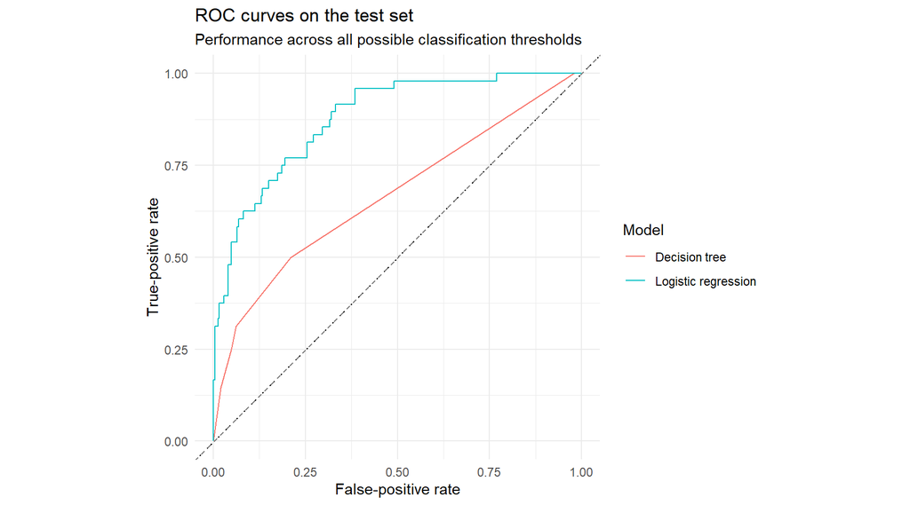

```r
bind_rows(
  logistic_predictions |> mutate(model = "Logistic regression"),
  tree_predictions |> mutate(model = "Decision tree")
) |>
  group_by(model) |>
  roc_curve(truth, .pred_yes, event_level = "second") |>
  autoplot() +
  geom_abline(linetype = "dashed", color = "gray50") +
  labs(
    title = "ROC curves on the test set",
    subtitle = "Performance across all possible classification thresholds",
    x = "False-positive rate",
    y = "True-positive rate",
    color = "Model"
  ) +
  theme_minimal()
```

# 9 8. Connect the threshold to HR capacity

The default threshold of 0.50 is a convention, not an operational requirement. Lower thresholds generally flag more employees and improve recall, but they also create more false positives and require more HR reviews.

```r
threshold_results <- function(predictions, model_name,
                              thresholds = seq(0.10, 0.70, by = 0.05)) {
  map_dfr(thresholds, function(cutoff) {
    scored <- predictions |>
      mutate(
        threshold = cutoff,
        classification = factor(
          if_else(.pred_yes >= cutoff, "Yes", "No"),
          levels = c("No", "Yes")
        )
      )

    tibble(
      model = model_name,
      threshold = cutoff,
      employees_flagged = sum(scored$classification == "Yes"),
      recall = sens_vec(
        scored$truth,
        scored$classification,
        event_level = "second"
      ),
      precision = precision_vec(
        scored$truth,
        scored$classification,
        event_level = "second"
      ),
      missed_attrition_cases = sum(
        scored$truth == "Yes" & scored$classification == "No"
      )
    )
  })
}

threshold_comparison <- bind_rows(
  threshold_results(logistic_predictions, "Logistic regression"),
  threshold_results(tree_predictions, "Decision tree")
)

threshold_comparison
```

```
## # A tibble: 26 × 6
##    model     threshold employees_flagged recall precision missed_attrition_cases
##    <chr>         <dbl>             <int>  <dbl>     <dbl>                  <int>
##  1 Logistic…      0.1                132  0.917     0.333                      4
##  2 Logistic…      0.15               107  0.833     0.374                      8
##  3 Logistic…      0.2                 82  0.75      0.439                     12
##  4 Logistic…      0.25                69  0.688     0.478                     15
##  5 Logistic…      0.3                 58  0.625     0.517                     18
##  6 Logistic…      0.35                51  0.625     0.588                     18
##  7 Logistic…      0.4                 45  0.583     0.622                     20
##  8 Logistic…      0.45                35  0.479     0.657                     25
##  9 Logistic…      0.5                 31  0.438     0.677                     27
## 10 Logistic…      0.55                28  0.396     0.679                     29
## # ℹ 16 more rows
```

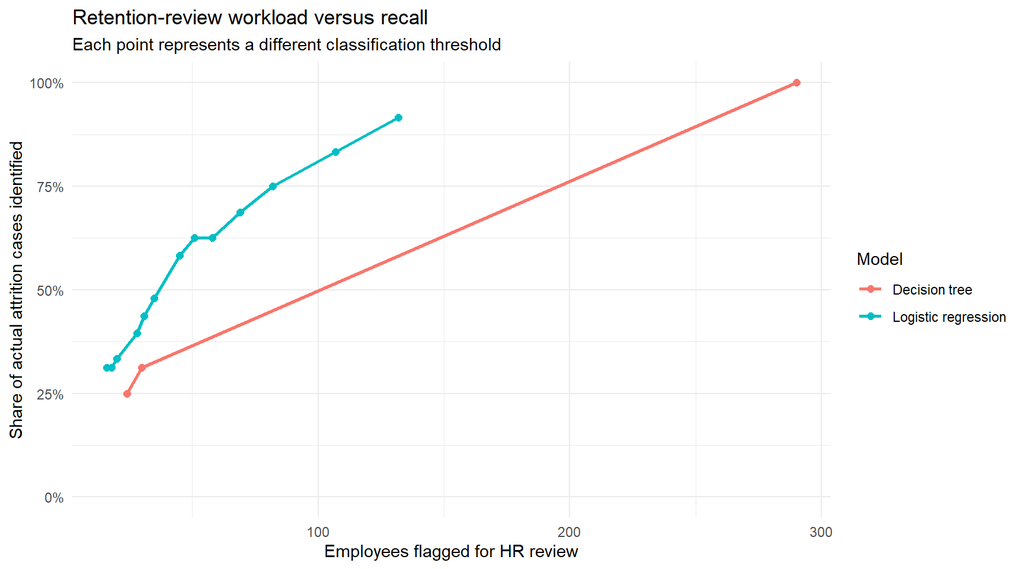

```r
threshold_comparison |>
  ggplot(aes(employees_flagged, recall, color = model)) +
  geom_line(linewidth = 1) +
  geom_point(size = 2) +
  scale_y_continuous(labels = percent, limits = c(0, 1)) +
  labs(
    title = "Retention-review workload versus recall",
    subtitle = "Each point represents a different classification threshold",
    x = "Employees flagged for HR review",
    y = "Share of actual attrition cases identified",
    color = "Model"
  ) +
  theme_minimal()
```

Suppose HR can review at most 20% of employees in the test population. The next table finds the feasible threshold with the highest recall for each model.

```r
review_capacity <- ceiling(0.20 * nrow(test_data))

recommended_thresholds <- threshold_comparison |>
  filter(employees_flagged <= review_capacity) |>
  group_by(model) |>
  slice_max(recall, n = 1, with_ties = FALSE) |>
  ungroup() |>
  arrange(desc(recall), desc(precision))

tibble(review_capacity = review_capacity)
```

```
## # A tibble: 1 × 1
##   review_capacity
##             <dbl>
## 1              59
```

```r
recommended_thresholds
```

```
## # A tibble: 2 × 6
##   model      threshold employees_flagged recall precision missed_attrition_cases
##   <chr>          <dbl>             <int>  <dbl>     <dbl>                  <int>
## 1 Logistic …      0.3                 58  0.625     0.517                     18
## 2 Decision …      0.15                30  0.312     0.5                       33
```

An alternative production process is to rank employees by predicted probability and review the top 59 employees. This directly matches workload to available capacity and avoids assuming that 0.50 is the right cutoff.

```r
best_model_name <- recommended_thresholds$model[[1]]

selected_predictions <- if (best_model_name == "Logistic regression") {
  logistic_predictions
} else {
  tree_predictions
}

review_list_summary <- selected_predictions |>
  mutate(test_row = row_number()) |>
  slice_max(.pred_yes, n = review_capacity, with_ties = FALSE) |>
  summarise(
    selected_model = best_model_name,
    employees_for_review = n(),
    actual_attrition_cases_captured = sum(truth == "Yes"),
    precision_within_review_list = mean(truth == "Yes")
  )

review_list_summary
```

```
##        selected_model employees_for_review actual_attrition_cases_captured
## 1 Logistic regression                   59                              31
##   precision_within_review_list
## 1                    0.5254237
```

For privacy, the lab reports an aggregate summary rather than displaying an employee-level watchlist.

# 10 9. Operational interpretation

Use the evidence generated above to answer these questions:

1. **Scale of the issue:** How many employees and what percentage of the workforce historically left?
2. **Workforce patterns:** Which roles or working conditions should HR study further? Are the affected groups large enough to prioritize?
3. **Baseline value:** Why is the majority-class accuracy an inadequate success measure for this use case?
4. **Model selection:** Which model identifies a larger share of actual attrition cases? Which one creates fewer unnecessary reviews?
5. **Capacity:** Under the 20% review constraint, which model and threshold should HR pilot?
6. **Interpretability:** Is the decision tree easier to communicate? Does that compensate for any difference in predictive performance?
7. **Intervention:** What supportive actions could HR test—for example workload discussions, career-path reviews, manager check-ins, or compensation review?
8. **Measurement:** How would HR determine whether an intervention actually reduces attrition rather than merely targeting correlated groups?

# 11 10. Recommended decision framework

The selected model should not automatically determine employment actions. A safer operational workflow is:

1. Score eligible employees at an agreed schedule.
2. Select a threshold or ranked review list based on HR capacity.
3. Let trained HR personnel review the surrounding context.
4. Offer supportive, consistently defined interventions.
5. Track participation, employee feedback, retention outcomes, false alarms, and missed cases.
6. Monitor performance and fairness across relevant employee groups.
7. Retrain or retire the model when its data or operating environment changes.

# 12 11. Key limitations

- The data is synthetic and does not represent a specific organization.
- Historical associations are not proof of causation.
- Some relevant factors may be unavailable or poorly measured.
- A random split estimates generalization to similar records, not necessarily performance in a future workforce. Production validation should use a time-based holdout when dates are available.
- Using employee data creates privacy, fairness, explainability, and governance obligations.
- Model performance may change as workforce policies and economic conditions change.

# 13 12. Optional learner exercises

1. Change the review capacity from 20% to 10% and 30%. How does the recommended threshold change?
2. Compare the zero-rule baseline with a one-rule classifier based on `over_time`.
3. Modify the decision tree’s `minsplit` or pruning rule. What happens to recall and interpretability?
4. Add 10-fold cross-validation to compare model stability.
5. Calculate specificity and balanced accuracy.
6. Examine model performance across gender groups using a separate audit table, without adding gender to the predictors.
7. Write a one-page recommendation to HR that distinguishes predictive associations from causal conclusions.